# Ozone Concentration Analysis

Ananda Kurth

2025-03-14

# Chapter 5 - Report Exercises

## 1. Introduction

This analysis focuses on daily Ozone measurements in New York from May to September 1973, specifically investigating:

> **How does wind speed affect Ozone concentration under high solar radiation conditions?**

## 2. Data Preparation

### 2.1 Load Libraries & Define Theme

```r
# Define a minimal theme
custom_theme <- theme_minimal() +
  theme(
    plot.title    = element_text(hjust = 0.5, face = "bold", size = 14),
    plot.subtitle = element_text(hjust = 0.5, face = "italic", size = 10),
    legend.position = "right"
  )

# Define color-blind–friendly palettes
qualitative_palette <- brewer.pal(8, "Set2")
diverging_palette   <- brewer.pal(5, "RdBu")
```

### 2.2 Load & Clean Data

The airquality dataset contains daily measurements (May–September 1973) of:

- Ozone (ppb)
- Solar.R (langleys/day)
- Wind (mph)
- Temp (°F)
- Month (numerical code 5–9)

I remove any rows with missing values in these columns, and convert Month from a numeric value to a factor with descriptive labels.

```r
# Load and clean data
df <- datasets::airquality |>
  filter(!is.na(Ozone), !is.na(Solar.R), !is.na(Wind), !is.na(Temp)) |>
  mutate(Month = factor(Month, labels = c("May", "Jun", "Jul", "Aug", "Sep")))
```

## 3. Exploratory Analysis

### 3.1 Data Overview

```r
# Summarize the dataset for an overview
summary(df)
```

```
##      Ozone          Solar.R           Wind            Temp       Month
##  Min.   :  1.0   Min.   :  7.0   Min.   : 2.30   Min.   :57.00   May:24
##  1st Qu.: 18.0   1st Qu.:113.5   1st Qu.: 7.40   1st Qu.:71.00   Jun: 9
##  Median : 31.0   Median :207.0   Median : 9.70   Median :79.00   Jul:26
##  Mean   : 42.1   Mean   :184.8   Mean   : 9.94   Mean   :77.79   Aug:23
##  3rd Qu.: 62.0   3rd Qu.:255.5   3rd Qu.:11.50   3rd Qu.:84.50   Sep:29
##  Max.   :168.0   Max.   :334.0   Max.   :20.70   Max.   :97.00
##       Day
##  Min.   : 1.00
##  1st Qu.: 9.00
##  Median :16.00
##  Mean   :15.95
##  3rd Qu.:22.50
##  Max.   :31.00
```

The wide range in Ozone (1–168 ppb) and solar radiation (7–334 langleys) suggests strong seasonal and meteorological variances.

### 3.2 Ozone Concentration by Month

Ozone typically peaks in summer. To confirm this seasonal pattern I create monthly Boxplots.

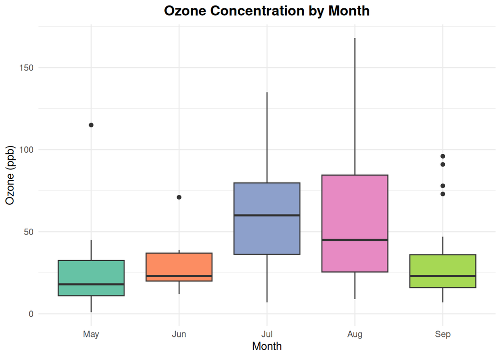

```r
# Visualize Ozone concentration by month
ggplot(df, aes(x = Month, y = Ozone, fill = Month)) +
  geom_boxplot() +
  scale_fill_manual(values = qualitative_palette) +
  custom_theme +
  theme(legend.position = "none") +
  labs(x     = "Month", y     = "Ozone (ppb)", title = "Ozone Concentration by Month")
```

> Interpretation:
- July shows the highest mean Ozone concentration.
- May has the lowest mean Ozone concentration.

This aligns with known dynamics: longer days and stronger sun in summer increase Ozone formation.

### 3.3 Correlation Analysis

Next, I compute pairwise correlations among the continuous variables (Ozone, Solar.R, Wind, Temp) to understand their relationships better.

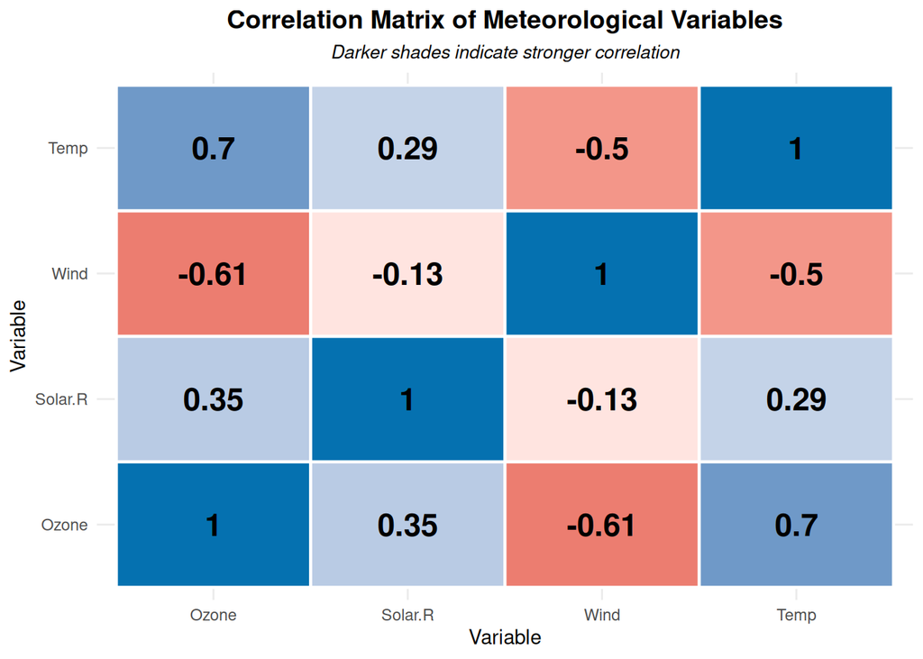

```r
# Calculate correlation matrix
corr_matrix <- df |> select(Ozone, Solar.R, Wind, Temp) |>
  cor(use = "complete.obs")

# Convert correlation matrix to a data frame for plotting
corr_df <- as.data.frame(as.table(corr_matrix))

# Visualize correlation matrix
ggplot(corr_df, aes(Var1, Var2, fill = Freq)) +
  geom_tile(color = "white", linewidth = 0.8) +
  geom_text(
    aes(label = round(Freq, 2)),
    color = "black",
    size = 6,
    fontface = "bold"
  ) +
  scale_fill_gradient2(
    low    = diverging_palette[1],
    mid    = "white",
    high   = diverging_palette[5],
    midpoint = 0,
    limits = c(-1, 1)
  ) +
  labs(
    title    = "Correlation Matrix of Meteorological Variables",
    subtitle = "Darker shades indicate stronger correlation",
    x        = "Variable",
    y        = "Variable"
  ) +
  custom_theme +
  theme(legend.position = "none")
```

> Interpretation:
- Ozone vs. Temp: strong positive correlation (r ≈ 0.70) -> Hot days produce more Ozone.
- Ozone vs. Wind: strong negative correlation (r ≈ –0.61) -> Higher wind speeds appear to disperse Ozone.
- Ozone vs. Solar.R: moderate positive correlation (r ≈ 0.35) -> Moderately more Ozone on sunny days
- Wind vs. Temp: moderate negative correlation (r ≈ –0.50) -> Windy days tend to be cooler.

These patterns suggest that Temperature and solar radiation promote Ozone formation, while wind suppresses or disperses it.

## 4. Focus on High Solar Radiation Days

Next, I isolate days on which the solar radiation exceeds its median value. On these “high‐solar” (sunny) days, we can better see how wind influences Ozone concentration and its Temperature dependence.

### 4.1 Categorize Wind Conditions and Filter High Solar

I create a new binary factor, WindCondition, that labels each day as “Windy” if Wind > median(Wind) and “Low Wind” otherwise. Then I filter the days with Solar.R > median(Solar.R) and label them as “High Solar Radiation.”

```r
df <- df |>
  mutate(WindCondition = ifelse(Wind > median(Wind, na.rm = TRUE), "Windy", "Low Wind"))

# Filter only days with Solar.R > median
df_high_solar <- df |> filter(Solar.R > median(Solar.R, na.rm = TRUE))
df_high_solar$SolarCondition <- "High Solar Radiation"
```

> The median‐based threshold ensures roughly half of the days qualify as “high‐solar.”  
> I now have a subset where solar radiation is consistently elevated, allowing me to compare Ozone under different wind conditions.

### 4.2 Average Ozone by Wind Condition (High Solar Days)

I then compute group summaries (mean_ozone, mean_wind) and visualize them in a Boxplot.

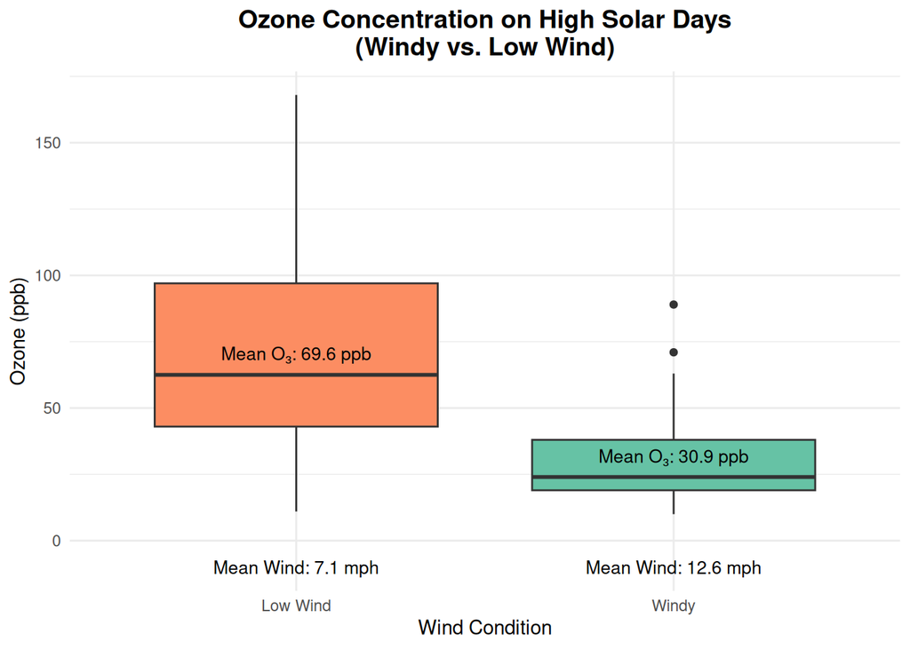

```r
# Summarize mean Ozone and mean wind by WindCondition
stats <- df_high_solar |>
  group_by(WindCondition) |>
  summarize(
    mean_ozone = mean(Ozone),
    mean_wind  = mean(Wind),
    .groups     = "drop"
  )

# Boxplot of Ozone by WindCondition, with annotations
ggplot(df_high_solar,
       aes(x = WindCondition, y = Ozone, fill = WindCondition)) +
  geom_boxplot() +
  # Annotate mean wind below each box
  geom_text(
    data = stats,
    aes(
      x = WindCondition,
      y = -10,
      label = paste0("Mean Wind: ", round(mean_wind, 1), " mph")
    ),
    color = "black",
    size = 3.5
  ) +
  # Annotate mean Ozone above each box
  geom_text(
    data = stats,
    aes(
      x = WindCondition,
      y = mean_ozone + 1,
      label = paste0("Mean O₃: ", round(mean_ozone, 1), " ppb")
    ),
    color = "black",
    size = 3.5
  ) +
  scale_fill_manual(values = c("Windy" = qualitative_palette[1], "Low Wind" = qualitative_palette[2])) +
  custom_theme +
  theme(legend.position = "none") +
  labs(x     = "Wind Condition", y     = "Ozone (ppb)", title = "Ozone Concentration on High Solar Days\n(Windy vs. Low Wind)")
```

> Interpretation:
- Low Wind days: Mean Ozone ≈ 69.6 ppb (wind ≈ 7.1 mph).
- Windy days: Mean Ozone ≈ 30.9 ppb (wind ≈ 12.6 mph).

The difference of ~40 ppb confirms the dispersing effect of wind on Ozone during high‐radiation days.

## 5. Ozone vs. Temperature by Wind Condition (High Solar)

Finally, I compare how Temperature on high solar days relates to the Ozone levels under low wind and high wind conditions.

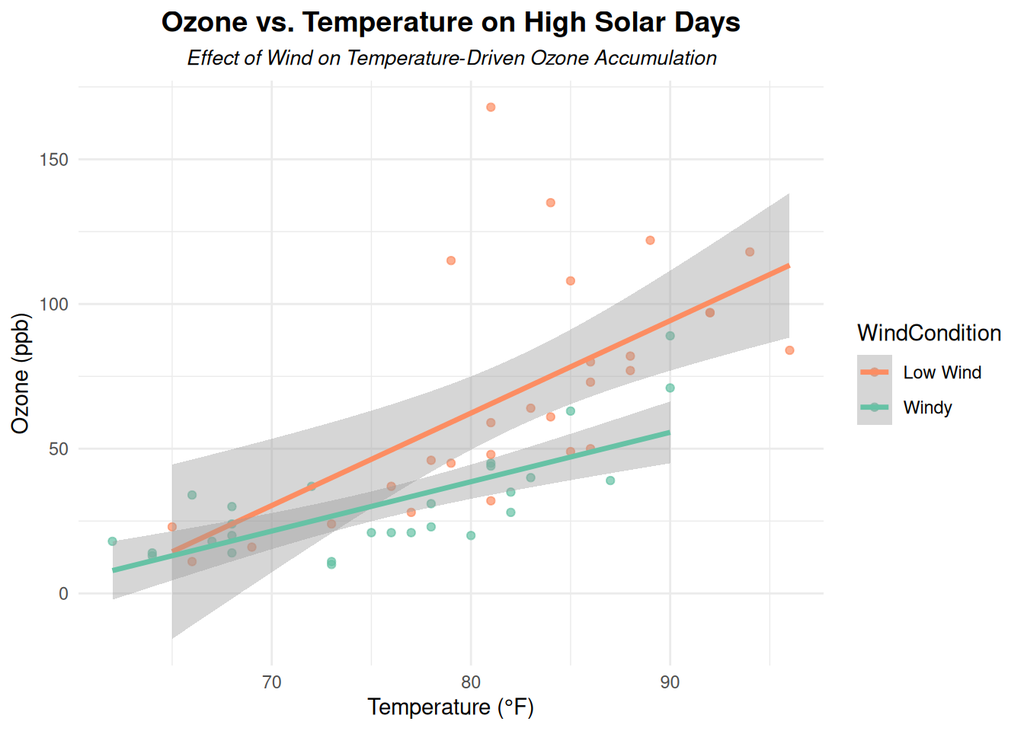

```r
# Scatterplot of Ozone vs. Temp colored by WindCondition
ggplot(df_high_solar, aes(x = Temp, y = Ozone, color = WindCondition)) +
  geom_point(alpha = 0.7) +
  geom_smooth(method = "lm",
              linewidth = 1.2,
              se = TRUE) +
  scale_color_manual(values = c("Windy" = qualitative_palette[1], "Low Wind" = qualitative_palette[2])) +
  custom_theme +
  labs(
    x        = "Temperature (°F)",
    y        = "Ozone (ppb)",
    title    = "Ozone vs. Temperature on High Solar Days",
    subtitle = "Effect of Wind on Temperature‐Driven Ozone Accumulation"
  )
```

> Interpretation:
- Under Low Wind, Ozone increases by ~64 ppb as Temperature rises from 70 °F to 90 °F.
- Under Windy, the corresponding increase is ~34 ppb.

This indicates that on very sunny days, windy conditions substantially limit Ozone build‐up, even as Temperature climbs. However, there are visible outliers between 80 °F and 85 °F.

## 6. Conclusions

The analysis shows that Ozone concentrations peak in July, correlating strongly with Temperature (0.70) and moderately with solar radiation (0.35), while negatively correlating with wind speed (-0.61).

On high solar radiation days, low wind conditions lead to an average Ozone level of 69.6 ppb, compared to 30.9 ppb on windy days, indicating that wind disperses Ozone. Ozone increases by 64 ppb with low wind as Temperatures rise from 70 °F to 90 °F, but only by 34 ppb under windy conditions.

Ultimately, wind speed seems to significantly reduces Ozone concentrations on sunny days. Low winds can lead to a sharp rise in Ozone, while strong winds limit this accumulation. However, the dataset only covers May to September of 1973, which may limit generalizability.